# Fallstudie Basecode Tutorial - Replication

# Run non-linear dimensional reduction (UMAP/tSNE)

Compared to the result in the tutorial the results from UMAP differs a bit. Here are 2 statements which we found during our online search:

- [LINK1](https://stackoverflow.com/questions/67101829/seurat-umap-visualization-result-is-mirrored-after-running-in-two-identical-envi): "The exact location of points on a UMAP plot can chance across different computers and OSs. We do our best to minimize any randomness to the procedure by fixing the random seed, but some fluctuation across systems is inevitable, and nothing to worry about.
- [LINK2](https://github.com/satijalab/seurat/issues/536)“I wouldn’t expect UMAP to be able to pick up R’s seed, as these are different environments. Running UMAP within R uses the reticulate package to call UMAP’s Python code from within R. Reticulate doesn’t automatically pass R’s random seed to Python, so there’s no reason to expect UMAP to pick up R’s random seed. However, this would be a good thing to allow users to set. As for the issue with random_state, that seems to be an issue with UMAP itself, not Seurat.”

This can result in slightly different UMAP results. What we found out that using the latest Seurat version it gives the same results, also for other students.

- UMAP

```r
# If you haven't installed UMAP, you can do so via reticulate::py_install(packages =
# 'umap-learn')
pbmc <- RunUMAP(pbmc, dims = 1:10)
```

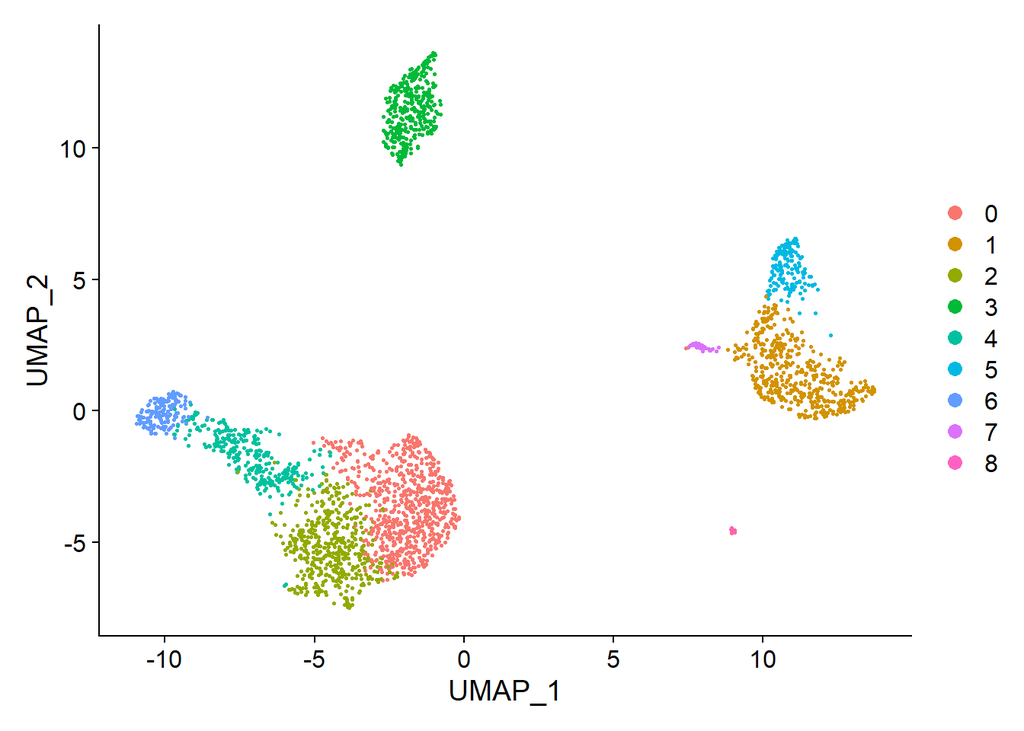

```r
# note that you can set `label = TRUE` or use the LabelClusters function to help label
# individual clusters
DimPlot(pbmc, reduction = "umap")
```

```r
#saveRDS(pbmc, file = "./pbmc_tutorial.rds")
```

- tSNE

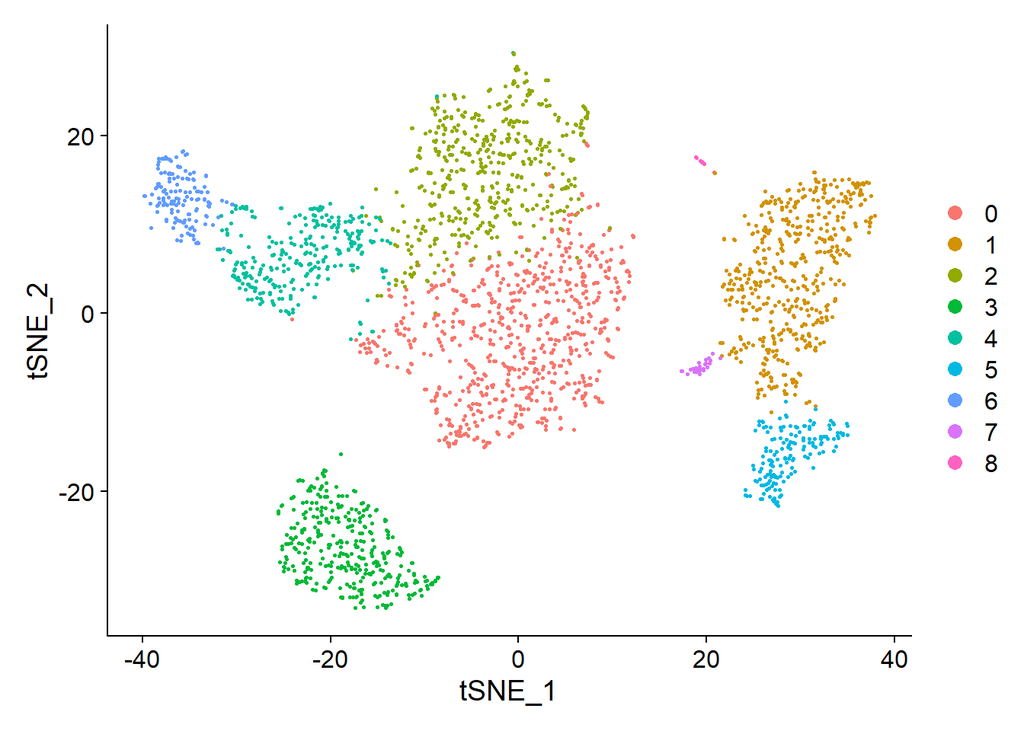

```r
#run TSNE
pbmc <- RunTSNE(pbmc, dims = 1:10)
TSNEPlot(pbmc)
```

# Finding differentially expressed features (cluster biomarkers)

To find markers (`FindMarkers`) which define a certain cluster DE (differential expression) is used. The parameter ident.1 defines the comparison/identification of cluster markers (positive or negative) compared to the other cells - e.g. ident.1 = 2 means that cluster2 is used - see below. [LINK](https://satijalab.org/seurat/reference/findmarkers)

Setting the `min.pct` argument - “min.pct argument requires a feature to be detected at a minimum percentage in either of the two groups of cells” - to 0 will increase the running time dramatically.

- find all markers of cluster 2

```r
# find all markers of cluster 2
cluster2.markers <- FindMarkers(pbmc, ident.1 = 2, min.pct = 0.25)
head(cluster2.markers, n = 5)
```

|  | p_val | avg_log2FC | pct.1 | pct.2 | p_val_adj |
| --- | --- | --- | --- | --- | --- |
| IL32 | 2.593535e-91 | 1.2154360 | 0.949 | 0.466 | 3.556774e-87 |
| LTB | 7.994465e-87 | 1.2828597 | 0.981 | 0.644 | 1.096361e-82 |
| CD3D | 3.922451e-70 | 0.9359210 | 0.922 | 0.433 | 5.379250e-66 |
| IL7R | 1.130870e-66 | 1.1776027 | 0.748 | 0.327 | 1.550876e-62 |
| LDHB | 4.082189e-65 | 0.8837324 | 0.953 | 0.614 | 5.598314e-61 |

- find all markers distinguishing cluster 5 from clusters 0 and 3

```r
# find all markers distinguishing cluster 5 from clusters 0 and 3
cluster5.markers <- FindMarkers(pbmc, ident.1 = 5, ident.2 = c(0, 3), min.pct = 0.25)
head(cluster5.markers, n = 5)
```

|  | p_val | avg_log2FC | pct.1 | pct.2 | p_val_adj |
| --- | --- | --- | --- | --- | --- |
| FCGR3A | 2.150929e-209 | 4.267579 | 0.975 | 0.039 | 2.949784e-205 |
| IFITM3 | 6.103366e-199 | 3.877105 | 0.975 | 0.048 | 8.370156e-195 |
| CFD | 8.891428e-198 | 3.411039 | 0.938 | 0.037 | 1.219370e-193 |
| CD68 | 2.374425e-194 | 3.014535 | 0.926 | 0.035 | 3.256286e-190 |
| RP11-290F20.3 | 9.308287e-191 | 2.722684 | 0.840 | 0.016 | 1.276538e-186 |

- find markers for every cluster compared to all remaining cells, report only the positive ones

```r
# find markers for every cluster compared to all remaining cells, report only the positive
# ones
pbmc.markers <- FindAllMarkers(pbmc, only.pos = TRUE, min.pct = 0.25, logfc.threshold = 0.25)
pbmc.markers %>%
    group_by(cluster) %>%
    slice_max(n = 2, order_by = avg_log2FC)
```

| p_val | avg_log2FC | pct.1 | pct.2 | p_val_adj | cluster | gene |
| --- | --- | --- | --- | --- | --- | --- |
| 1.167632e-83 | 1.333503 | 0.435 | 0.108 | 1.601290e-79 | 0 | CCR7 |
| 1.740957e-109 | 1.069166 | 0.897 | 0.593 | 2.387549e-105 | 0 | LDHB |
| 0.000000e+00 | 5.570063 | 0.996 | 0.215 | 0.000000e+00 | 1 | S100A9 |
| 0.000000e+00 | 5.477394 | 0.975 | 0.121 | 0.000000e+00 | 1 | S100A8 |
| 7.994465e-87 | 1.282860 | 0.981 | 0.644 | 1.096361e-82 | 2 | LTB |
| 2.610017e-59 | 1.240361 | 0.424 | 0.111 | 3.579377e-55 | 2 | AQP3 |
| 0.000000e+00 | 4.310172 | 0.936 | 0.041 | 0.000000e+00 | 3 | CD79A |
| 9.481783e-271 | 3.591579 | 0.622 | 0.022 | 1.300332e-266 | 3 | TCL1A |
| 4.932509e-169 | 3.006739 | 0.595 | 0.056 | 6.764443e-165 | 4 | GZMK |
| 1.167095e-178 | 2.966206 | 0.957 | 0.241 | 1.600553e-174 | 4 | CCL5 |

[output cut: 8 more lines]

- For testing DE Seurat has several options which can be defined via the parameter `test.use`. In this case ROC test, which “returns the ‘classification power’ for any individual marker” was chosen.

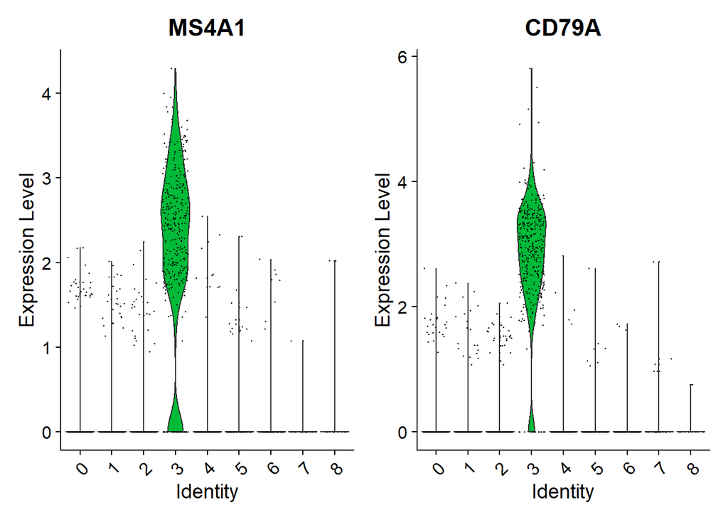

```r
cluster0.markers <- FindMarkers(pbmc, ident.1 = 0, logfc.threshold = 0.25, test.use = "roc", only.pos = TRUE)
VlnPlot(pbmc, features = c("MS4A1", "CD79A"))
```

- Also the plotting of the raw counts is possible.

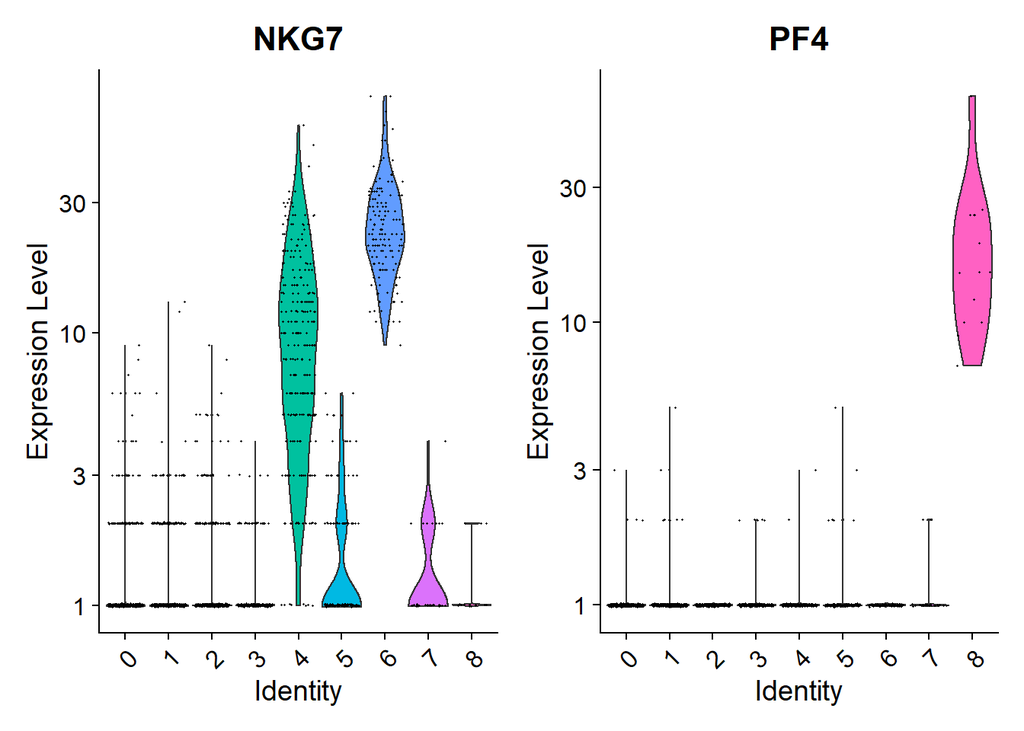

```r
# you can plot raw counts as well
VlnPlot(pbmc, features = c("NKG7", "PF4"), slot = "counts", log = TRUE)
```

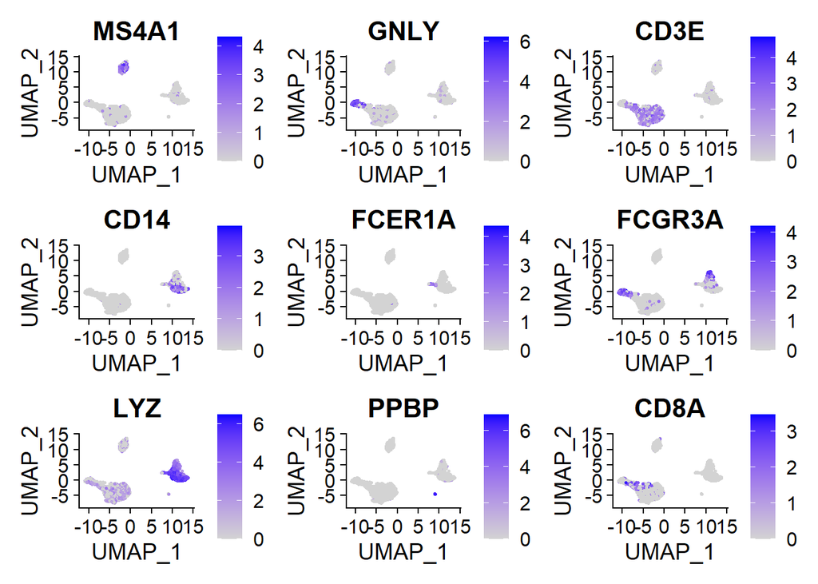

```r
FeaturePlot(pbmc, features = c("MS4A1", "GNLY", "CD3E", "CD14", "FCER1A", "FCGR3A", "LYZ", "PPBP",
    "CD8A"))
```

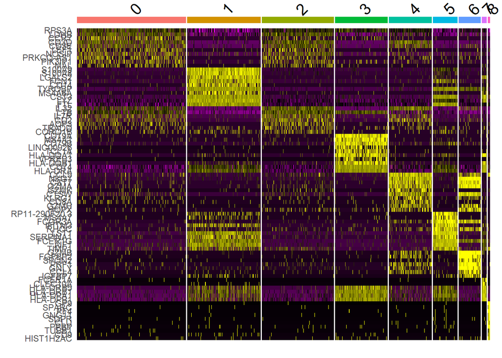

```r
pbmc.markers %>%
    group_by(cluster) %>%
    top_n(n = 10, wt = avg_log2FC) -> top10
DoHeatmap(pbmc, features = top10$gene) + NoLegend()
```

# Assigning cell type identity to clusters

In the last step markers can be manually assigned to cell types and used for labelling the clusters in UMAP. This manual assignment is a bit tricky and is discussed in the file where we applied this workflow to a new data-set.

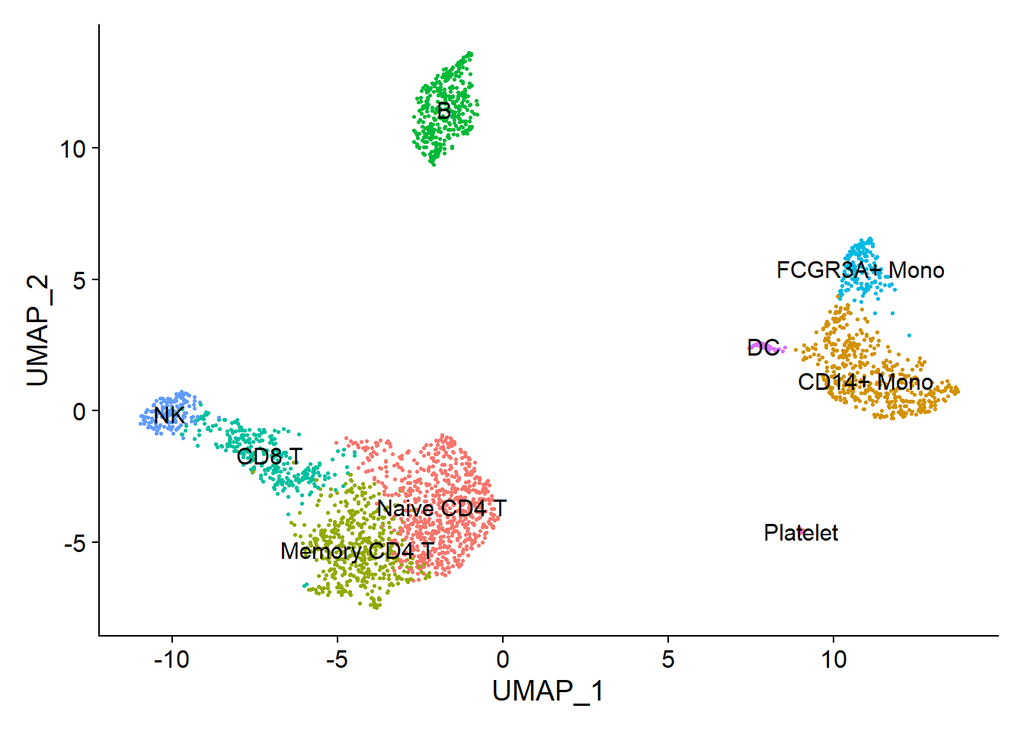

```r
new.cluster.ids <- c("Naive CD4 T", "CD14+ Mono", "Memory CD4 T", "B", "CD8 T", "FCGR3A+ Mono",
    "NK", "DC", "Platelet")
names(new.cluster.ids) <- levels(pbmc)
pbmc <- RenameIdents(pbmc, new.cluster.ids)
DimPlot(pbmc, reduction = "umap", label = TRUE, pt.size = 0.5) + NoLegend()
```